# Practical 2: Spatial Relationships

Rocco Bowman

6/3/2021

## 2.0 Introduction

In this lesson, we will practice some concepts of spatial relationships and topology. For example, while we can easily filter and subset tabular data and shapefiles, we might also want to subset spatial data based on how they intersect. We might also want to create catchment areas or buffers to select all points within a radius or calculate distances from all points to a feature for regression.

## 2.1 Intersection

In the previous lesson, we overlaid two shapefiles to compare their spatial locations. Now we want to make relations between these data in space and shuttle information from one dataset to the other. We will load our packages then assign the object **nz** the New Zealand boundaries data set and the heighest points in the country found in the **spData** package.

```r
library(sf)
```

```r
library(tidyverse) # includes dplyr and ggplot2
library(spData) # contains the New Zealand (nz) dataset
nz <- nz
heights <- nz_height

head(nz)
```

```
## Simple feature collection with 6 features and 6 fields
## Geometry type: MULTIPOLYGON
## Dimension:     XY
## Bounding box:  xmin: 1568217 ymin: 5518431 xmax: 2089533 ymax: 6191874
## Projected CRS: NZGD2000 / New Zealand Transverse Mercator 2000
##            Name Island Land_area Population Median_income Sex_ratio
## 1     Northland  North 12500.561     175500         23400 0.9424532
## 2      Auckland  North  4941.573    1657200         29600 0.9442858
## 3       Waikato  North 23900.036     460100         27900 0.9520500
## 4 Bay of Plenty  North 12071.145     299900         26200 0.9280391
## 5      Gisborne  North  8385.827      48500         24400 0.9349734
## 6   Hawke's Bay  North 14137.524     164000         26100 0.9238375
##                             geom
## 1 MULTIPOLYGON (((1745493 600...
## 2 MULTIPOLYGON (((1803822 590...
## 3 MULTIPOLYGON (((1860345 585...
## 4 MULTIPOLYGON (((2049387 583...
## 5 MULTIPOLYGON (((2024489 567...
## 6 MULTIPOLYGON (((2024489 567...
```

```r
head(heights)
```

```
## Simple feature collection with 6 features and 2 fields
## Geometry type: POINT
## Dimension:     XY
## Bounding box:  xmin: 1204143 ymin: 5048309 xmax: 1389460 ymax: 5168749
## Projected CRS: NZGD2000 / New Zealand Transverse Mercator 2000
##   t50_fid elevation                geometry
## 1 2353944      2723 POINT (1204143 5049971)
## 2 2354404      2820 POINT (1234725 5048309)
## 3 2354405      2830 POINT (1235915 5048745)
## 4 2369113      3033 POINT (1259702 5076570)
## 5 2362630      2749 POINT (1378170 5158491)
## 6 2362814      2822 POINT (1389460 5168749)
```

The heights data is a **POINT** vector while the NZ boundaries is a **MULTIPOLYGON** vector. If we want to find and attach which NZ province they are found, we need to perform a spatial join.

Now, as before, we can plot these data so that they overlap. First we compare CRS, then use **ggplot** to layer. We can also see that the CRS are the same from the **head** calls above (NZGD2000 / New Zealand Transverse Mercator 2000).

```r
st_crs(nz) == st_crs(heights)
```

```
## [1] TRUE
```

Labeling shapefile polygons is not straight forward in **ggplot** so what we can do is extracted the coordinates for the centroids of the NZ layer then attach the **Names** column to them from the original shapefile so that each name is matched with it’s coordinates.

```r
coords <- data.frame(st_coordinates(st_centroid(nz)))
coords_df <- coords %>%
  mutate(Name = nz$Name, .before = X)
```

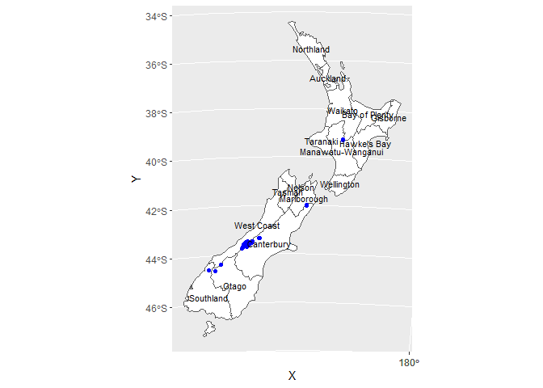

```r
ggplot() +
  geom_sf(data = nz, fill = "white") +
  geom_sf(data = heights, color = "blue") +
  geom_text(data = coords_df,aes(X, Y, label=Name), size = 3)
```

Using other mapping packages might work better if your goal is simply to make a map. The **tmap** package functions more like a dedicated GIS software layout manager and allows you to easily label parts and add scale bars, compass, and more with minimal code.

```r
library(tmap)
tm_shape(nz) +
  tm_polygons() +
  tm_text("Name", size = 0.6)+
tm_shape(heights)+
  tm_dots(size = 0.1, col = "red") +
tmap_style("natural") +
  tm_compass(type = "8star")+
  tm_scale_bar(breaks = c(0, 100, 200, 300))
```

```
## tmap style set to "natural"
```

```
## other available styles are: "white", "gray", "cobalt", "col_blind", "albatross", "beaver", "bw", "classic", "watercolor"
```

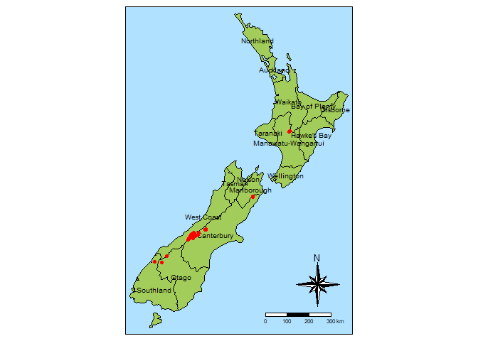

Now that we have our shapefiles and we have visualized their intersection, we can use the **st_intersection** function to join the data by location. We can attach the province names to the point heights. We just need to insert our polygon coverage as the first argument, then the heights shapefile.

We might also want to remove some irrelevant columns relating to population and so on. We can use **dplyr’s** **select** function to choose just the columns we want by name.

```r
intersection <- st_intersection(nz, heights) %>%
  select(Name,Island,elevation, geom)
intersection
```

```
## Simple feature collection with 101 features and 3 fields
## Geometry type: POINT
## Dimension:     XY
## Bounding box:  xmin: 1204143 ymin: 5048309 xmax: 1822492 ymax: 5650492
## Projected CRS: NZGD2000 / New Zealand Transverse Mercator 2000
## First 10 features:
##            Name Island elevation                    geom
## 13    Southland  South      2723 POINT (1204143 5049971)
## 12        Otago  South      2820 POINT (1234725 5048309)
## 12.1      Otago  South      2830 POINT (1235915 5048745)
## 10   West Coast  South      3033 POINT (1259702 5076570)
## 11   Canterbury  South      2749 POINT (1378170 5158491)
## 11.1 Canterbury  South      2822 POINT (1389460 5168749)
## 11.2 Canterbury  South      2778 POINT (1390166 5169466)
## 11.3 Canterbury  South      3004 POINT (1372357 5172729)
## 11.4 Canterbury  South      3114 POINT (1372062 5173236)
## 11.5 Canterbury  South      2882 POINT (1372810 5173419)
```

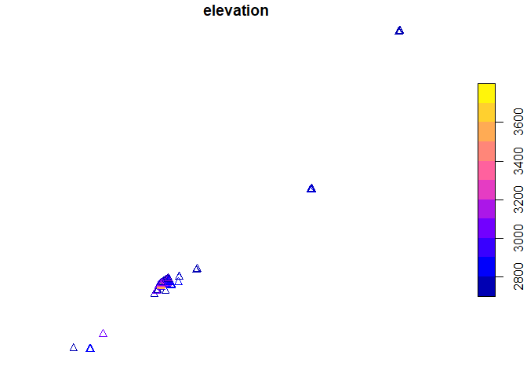

```r
plot(intersection["elevation"], pch = 2)
```

If we wanted, say, only the heights for Canterbury, we could also easily filter our new resutlts. However, **intersection** not only joins attributes but can be used to select only those spatial features that overlap, removing a step in between.

```r
canterbury <- nz %>%
  filter(Name == "Canterbury")

heights_canterbury <- st_intersection(canterbury,heights)
```

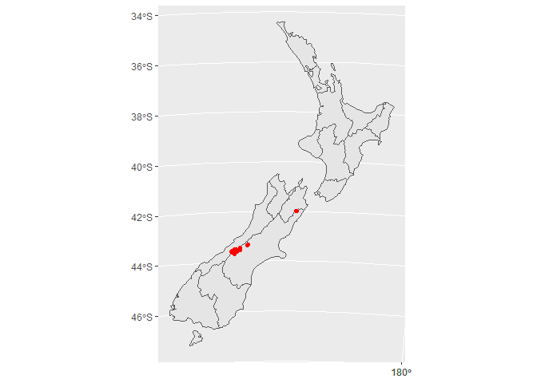

```r
ggplot() +
  geom_sf(data = nz) +
  geom_sf(data = heights_canterbury, color = "red")
```

## 2.2 Difference

Difference is the opposite of intersection in that it removes any overlapping areas and weirdly joins the data from the removed feature. For example, we can remove Canterbury from our shapefile by entering it as the second argument of **st_difference**.

```r
difference <- st_difference(nz,canterbury)
difference
```

```
## Simple feature collection with 15 features and 12 fields
## Geometry type: GEOMETRY
## Dimension:     XY
## Bounding box:  xmin: 1090144 ymin: 4748537 xmax: 2089533 ymax: 6191874
## Projected CRS: NZGD2000 / New Zealand Transverse Mercator 2000
## First 10 features:
##                 Name Island Land_area Population Median_income Sex_ratio
## 1          Northland  North 12500.561     175500         23400 0.9424532
## 2           Auckland  North  4941.573    1657200         29600 0.9442858
## 3            Waikato  North 23900.036     460100         27900 0.9520500
## 4      Bay of Plenty  North 12071.145     299900         26200 0.9280391
## 5           Gisborne  North  8385.827      48500         24400 0.9349734
## 6        Hawke's Bay  North 14137.524     164000         26100 0.9238375
## 7           Taranaki  North  7254.480     118000         29100 0.9569363
## 8  Manawatu-Wanganui  North 22220.608     234500         25000 0.9387734
```

[output cut: 24 more lines]

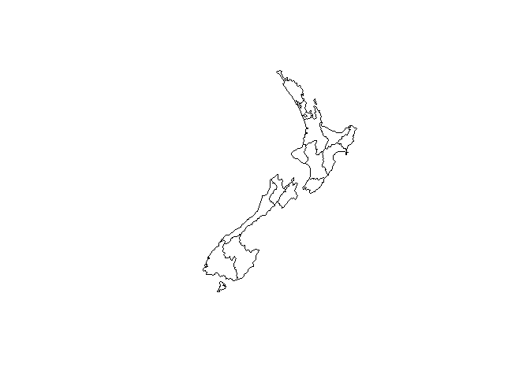

```r
plot(st_geometry(difference))
```

## 2.3 Convex Hull (Connecting the Dots)

You may want to specify a zoom level or study area to best capture your data or maybe to highlight certain data points. We can use our preexisting elevation points to demarcate a study area with a **convex hull**. A convex hull connects points in order to form the tightest envelope.

First, we need to perform a **union** on the points so that they become a single **MULTIPOINT** vector. We then call **st_convex_hull** and enter our union object as the argument.

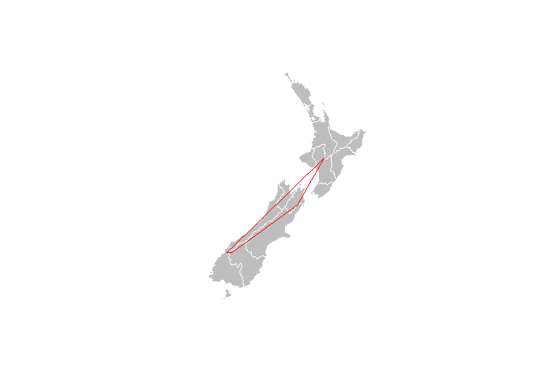

```r
# Compute the tight bounding box
union <- st_union(heights)
convex_hull <- st_convex_hull(union)

# Plot the points together with the hull
plot(st_geometry(nz), col = "grey", border = "white")
plot(convex_hull, border = "red", add = TRUE)
```

If you want to make a minimum bounding box for polygons, you first need to generate **centroids**, or center points, before calling union and st_convex_hull commands.

```r
# Compute the neighborhood centroids
centroids <- st_centroid(nz)
```

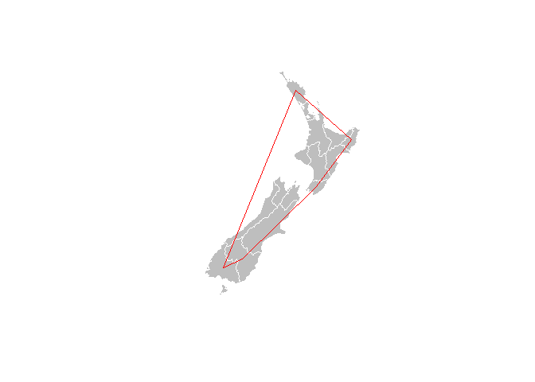

```r
# Compute the tight bounding box
union <- st_union(centroids)
convex_hull <- st_convex_hull(union)

# Plot the points together with the hull
plot(st_geometry(nz), col = "grey", border = "white")
plot(convex_hull, border = "red", add = TRUE)
```

## 2.4 Cropping and Bounding Boxes

Another way to focus the map on only the data of interest without subsetting or using convex hulls is by cropping data by using the bounding box of another. This has the advantage of keeping adjacent spatial data but focusing on just the part of interest. For example, if we only have rental observation points for Manhattan, our **nybb** shapefile for all of New York is going to make the map too zoomed-out like below:

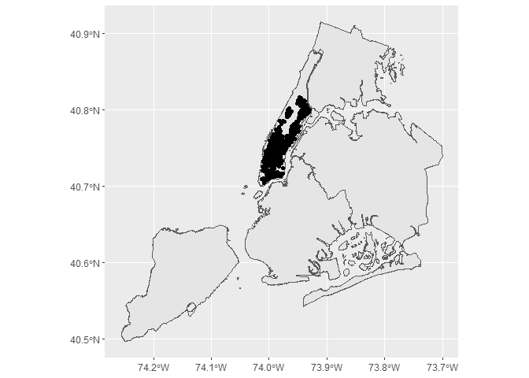

We might want to have parts of the surrounding boroughs visible in our map for context. In this case, we can read in the data as usual, make sure both sets are in the same CRS, and convert the rental observations to shapefiles. Then we can use **st_bbox** to extract the minimum bounding box that covers the geographic extent of the points and use **st_crop** to crop the NYC boundaries in order to focus on the observation data.

```r
nyc <- st_read("Day 2/data/nybb.shp") %>%
  st_transform(nyc, crs = 4326)
bbox <- st_bbox(rent_points)

cropped <- st_crop(nyc, bbox)
```

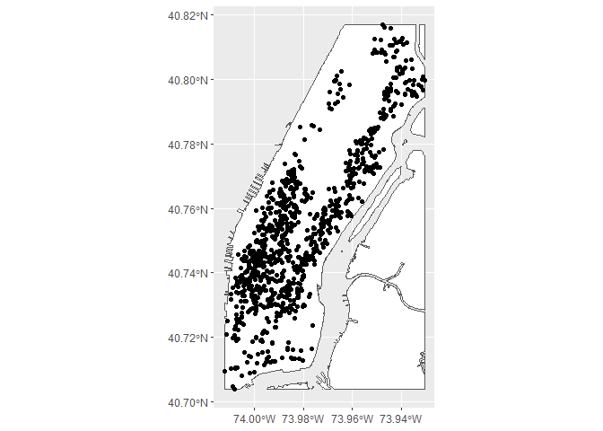

```r
ggplot() +
  geom_sf(data = cropped, fill = "white") +
  geom_sf(data = rent_points)
```

This might cut off too much of Manhattan for your liking. We could also get the bounding box for the Manhattan borough so as to make sure we *at least* get all of Manhattan. We can use an in-line **filter** function without needing to make a separate object.

```r
bbox <- st_bbox(nyc %>% filter(BoroName == "Manhattan"))

cropped <- st_crop(nyc, bbox)
```

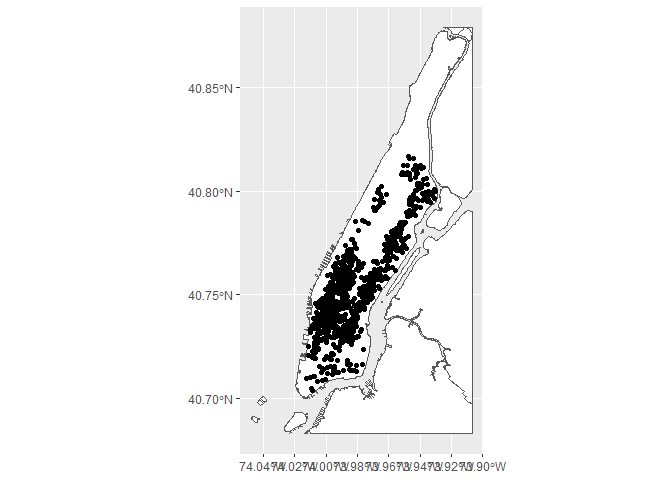

```r
ggplot() +
  geom_sf(data = cropped, fill = "white") +
  geom_sf(data = rent_points)
```

## 2.5 Buffer

Buffering allows the user to create a “buffer” or extension of any vector. For points, this means creating one, or several, circular vectors surrounding the vector at a regular redius. For polygons, buffers simply make a larger version of the vector at a regular radius.

Buffers can be useful for creating catchment areas or areas where one can count or aggregate data at a distance from the vector. For example, we can count how many subway stations are within 1000 feet of a rental point.

Our rental points are currently in WGS1984 CRS or EPSG 4326. This is a geographic coordinate system in decimal degrees. Instead, we will need a projected coordinate system measured in feet such as New York Long Island. Then we can use **st_buffer** and specify the **dist** or “distance” argument as 1000. The distance will be in the unit of your projection which may be feet, meters, kilometers, etc.

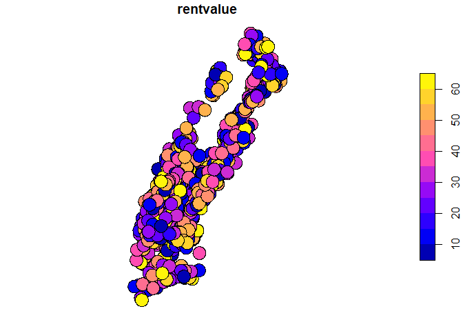

```r
rent_trans <- st_transform(rent_points, crs = 2263)
buffer <- st_buffer(rent_trans, dist = 1000)
plot(buffer["rentvalue"])
```

Next we can load in our subway stop data which is another point vector. We can plot it with the cropped version of NYC as well.

```r
subway <- st_read("Day 2/data/stops_nyc_subway.shp") %>%
  st_transform(crs = st_crs(cropped)) %>%
  st_crop(cropped %>% filter(BoroName == "Manhattan"))
```

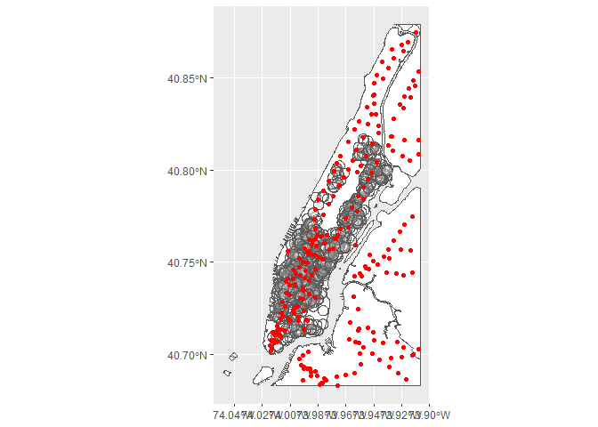

```r
ggplot() +
  geom_sf(data = cropped, fill = "white") +
  geom_sf(data = buffer, alpha = 0.1) +
  geom_sf(data = subway, color = "red")
```

Next we can use the buffers to “count” the number of subway stops within 1000 feet of an apartment using a combination of **st_intersects** and **lengths**. When we call the former, we get lists of all the subways stations within each buffer. When we call the latter, we get the absolute number of stations which is then appended as a new column in our buffer vector.

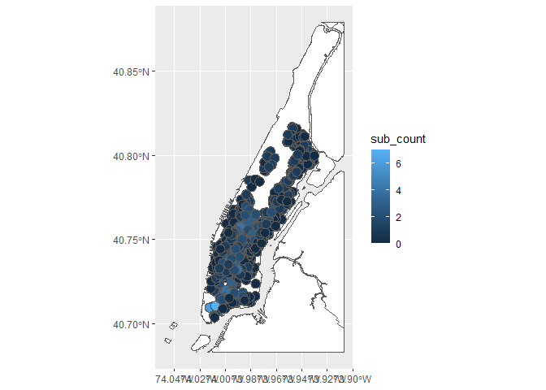

```r
subway <- st_transform(subway, crs = st_crs(buffer))

buffer$sub_count <- lengths(st_intersects(buffer, subway))

ggplot() +
  geom_sf(data = cropped, fill = "white") +
  geom_sf(data = buffer, aes(fill = sub_count))
```

## 2.6 Hexgrids

Creating catchment areas can be done regularly across the study area as well. Hexbinning are one such method that generates a hexagonal grid that can serve to aggregate or describe the distribution of data.The benefit of hexagons is that they tend to share several edges with other bins. Hexagonal and square grids can be particularly useful when spatial units (such as census tracts) change over time too often to make temporal comparison easy.

We can use **st_make_grid** to first generate a regular coverage of hexagons based on our rental points. We will set cellsize to 1000 like our buffers, set **square =** to FALSE to make hexagons.

```r
st_crs(rent_trans)
```

```
## Coordinate Reference System:
##   User input: EPSG:2263
##   wkt:
## PROJCRS["NAD83 / New York Long Island (ftUS)",
##     BASEGEOGCRS["NAD83",
##         DATUM["North American Datum 1983",
##             ELLIPSOID["GRS 1980",6378137,298.257222101,
##                 LENGTHUNIT["metre",1]]],
##         PRIMEM["Greenwich",0,
##             ANGLEUNIT["degree",0.0174532925199433]],
##         ID["EPSG",4269]],
##     CONVERSION["SPCS83 New York Long Island zone (US Survey feet)",
##         METHOD["Lambert Conic Conformal (2SP)",
##             ID["EPSG",9802]],
##         PARAMETER["Latitude of false origin",40.1666666666667,
##             ANGLEUNIT["degree",0.0174532925199433],
##             ID["EPSG",8821]],
##         PARAMETER["Longitude of false origin",-74,
##             ANGLEUNIT["degree",0.0174532925199433],
##             ID["EPSG",8822]],
##         PARAMETER["Latitude of 1st standard parallel",41.0333333333333,
##             ANGLEUNIT["degree",0.0174532925199433],
##             ID["EPSG",8823]],
##         PARAMETER["Latitude of 2nd standard parallel",40.6666666666667,
##             ANGLEUNIT["degree",0.0174532925199433],
##             ID["EPSG",8824]],
##         PARAMETER["Easting at false origin",984250,
##             LENGTHUNIT["US survey foot",0.304800609601219],
##             ID["EPSG",8826]],
##         PARAMETER["Northing at false origin",0,
##             LENGTHUNIT["US survey foot",0.304800609601219],
##             ID["EPSG",8827]]],
##     CS[Cartesian,2],
##         AXIS["easting (X)",east,
##             ORDER[1],
##             LENGTHUNIT["US survey foot",0.304800609601219]],
##         AXIS["northing (Y)",north,
##             ORDER[2],
##             LENGTHUNIT["US survey foot",0.304800609601219]],
##     USAGE[
##         SCOPE["Engineering survey, topographic mapping."],
##         AREA["United States (USA) - New York - counties of Bronx; Kings; Nassau; New York; Queens; Richmond; Suffolk."],
##         BBOX[40.47,-74.26,41.3,-71.8]],
##     ID["EPSG",2263]]
```

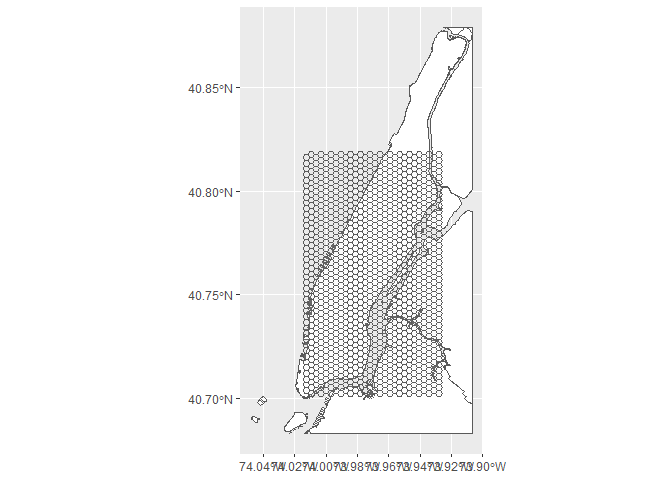

```r
hexgrid <- st_make_grid(rent_trans, cellsize = 1000, square = FALSE, flat_topped = TRUE)

ggplot() +
  geom_sf(data = cropped, fill = "white") +
  geom_sf(data = hexgrid, alpha = 0.1)
```

Our hex grid is not an sf object though and must first be converted using **st_sf**. Then we get our subway points into the New York Long Island projection. We can once again use **intersect** to collect data into our hexbins but this only tells us *which* subway stops are captured. We can combine this with **lengths** to tally those stops.

**Notice that this is “lengths” and not “length”. Lengths will tally each list of subway stops while length only report the length of a single vector**

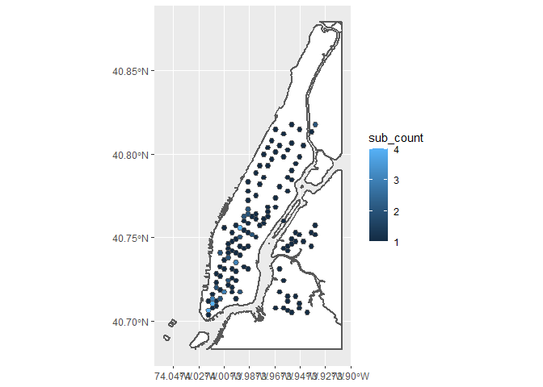

```r
hexgrid_sf <- st_sf(hexgrid)

subway <- st_transform(subway, crs = 2263)

hexgrid_sf$sub_count <- lengths(st_intersects(hexgrid_sf, subway))

ggplot() +
  geom_sf(data = cropped, fill = "white", lwd = 1) +
  geom_sf(data = hexgrid_sf %>% filter(sub_count > 0), aes(fill = sub_count))
```

## 2.7 Voronoi (Thiessen) Polygons

Square grids and hex bins can make a regular surface from vector data but here is also the **Voronoi or Thiessen polygon** treatment. These polygons create dynamic “territories” for each point in a vector, each of which only includes the area closest to each point. This is a common strategy for aggregating data into polygons.

Creating a voronoi diagram is not straight-forward in **R** and some manipulations are necessary. First we need to match CRS with our cropped basemap, then take our subway points, drop its geometry with **st_drop_geometry**, select the lat and long variables, unlist the data frame into a long vector, transform it back into a matrix, then convert it to a **MULTIPOINT** vector. Pretty confusing. But then all we need to do is run **st_voronoi** on our points shapefile and **st_collection_extract()** to convert the XY points to empty polygons.

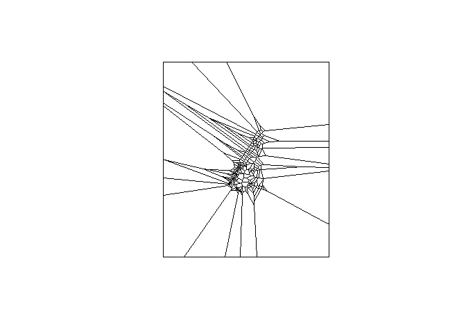

```r
subway <- st_transform(subway, crs = st_crs(cropped))

points <- subway %>%
  st_drop_geometry() %>%
  select(stop_lon,stop_lat) %>%
  unlist() %>%
  matrix(ncol = 2) %>%
  st_multipoint()

# Voronoi tesselation
voronoi_grid <- st_voronoi(points) %>%
  st_collection_extract()

plot(voronoi_grid, col = NA)
```

As if that wasn’t enough, we now need to convert the voronoi grid from an **sfc** object to an sf object in order to perform the intersection in the way we did it before. We can convert it with **st_as_sf** and feed in our voronoi grid object.

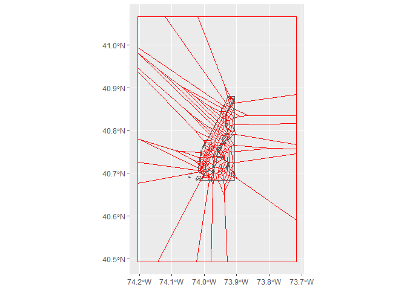

```r
voronoi_sf <- st_as_sf(voronoi_grid)
st_crs(voronoi_sf) <- st_crs(cropped)

ggplot() +
  geom_sf(data = cropped)+
  geom_sf(data = voronoi_sf, fill = NA, color = "red")
```

We can see that the voronoi diagram has a very large extent and it would be best to focus it on only where we have rental data for — Manahttan.We use **st_intersection** to accomplish this. Next, we call **aggregate** from the **sf** package and supply **mean** for the function argument.

If you get an error when running the **st_intersection** below (sf 1.0), you need to run **sf_use_s2(FALSE)** first.

```r
manhattan <- cropped %>%
  filter(BoroName == "Manhattan")

sf_use_s2(FALSE)
```

```
## Spherical geometry (s2) switched off
```

```r
voronoi_cropped <- st_intersection(voronoi_sf,manhattan)
```

```
## although coordinates are longitude/latitude, st_intersection assumes that they are planar
```

```r
agg <- aggregate(rent_points, voronoi_cropped, FUN = mean)
```

```
## although coordinates are longitude/latitude, st_intersects assumes that they are planar
```

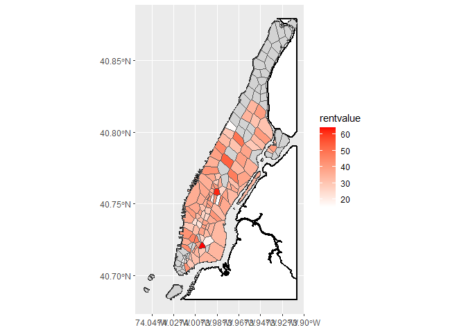

```r
ggplot() +
  geom_sf(data = cropped, color = "black", fill = "white", lwd = 1) +
  geom_sf(data = agg, aes(fill = rentvalue)) +
  scale_fill_continuous(low = "white", high = "red", na.value="lightgrey")
```

## 2.8 Other Geometric Calculations

When dealing with polygons, area will likely be one of the most important attributes related to them. This is because if you are dealing with a variable like population, you really need to be calculating population per square mile or some other combination of continuous variable and spatial area to standardize the measure. We can use **st_area** to assign an area column.

```r
merced_bos <- st_read("Day 2/data/BOS.shp")
head(merced_bos)
```

```
## Simple feature collection with 5 features and 5 fields
## Geometry type: POLYGON
## Dimension:     XY
## Bounding box:  xmin: -121.2487 ymin: 36.74039 xmax: -120.0521 ymax: 37.63337
## Geodetic CRS:  WGS 84
##   OBJECTID          electedoff name districtid         repname1
## 1        1 Board of Supervisor <NA>          1 Rodrigo Espinoza
## 2        2 Board of Supervisor <NA>          4    Lloyd Pareira
## 3        3 Board of Supervisor <NA>          5   Scott Silveira
## 4        4 Board of Supervisor <NA>          2     Josh Pedrozo
## 5        5 Board of Supervisor <NA>          3   Daron McDaniel
##                         geometry
## 1 POLYGON ((-120.5824 37.1858...
## 2 POLYGON ((-121.0675 37.2314...
## 3 POLYGON ((-120.6155 37.186,...
## 4 POLYGON ((-120.5048 37.308,...
## 5 POLYGON ((-120.5953 37.3895...
```

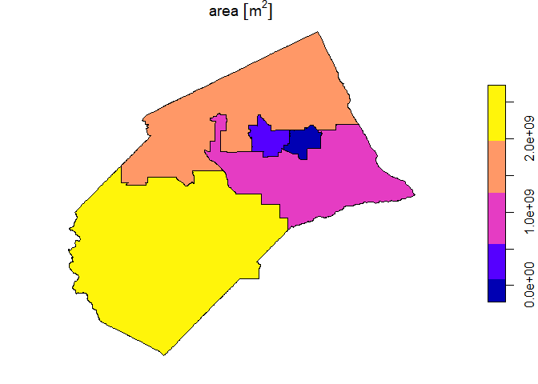

```r
merced_bos$area <- st_area(merced_bos)

plot(merced_bos["area"])
```

One can also easily find center points of polygons with **st_centroid** which may be helpful in some analyses. If you get a warning message, it just means that all the data that was represented for an area is now represented only as one point.

```r
merced_centroids <- st_centroid(merced_bos)
```

```
## Warning in st_centroid.sf(merced_bos): st_centroid assumes attributes are
## constant over geometries of x
```

```
## Warning in st_centroid.sfc(st_geometry(x), of_largest_polygon =
## of_largest_polygon): st_centroid does not give correct centroids for longitude/
## latitude data
```

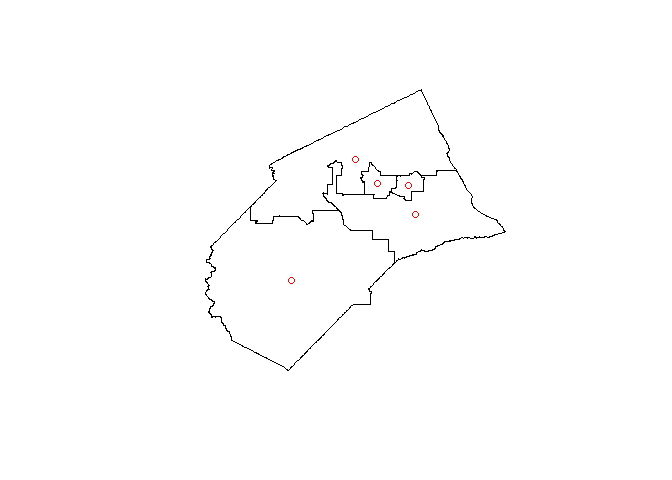

```r
plot(st_geometry(merced_bos))
plot(st_geometry(merced_centroids), col = "red", add = TRUE)
```

Lastly, sometimes you might want to find the “mean center” or the center of all data points. On its own, it will assume equal weights.

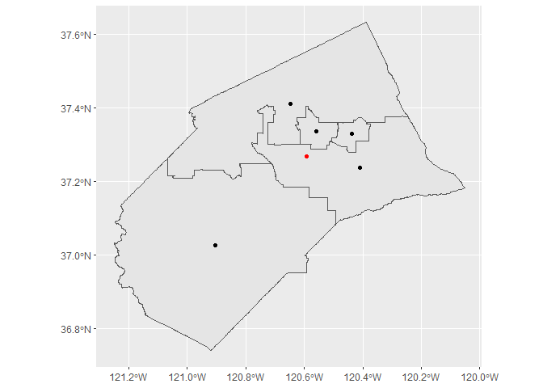

```r
coords <- data.frame(st_coordinates(merced_centroids))
mean_center_df <- tibble(mean_x = mean(coords$X), mean_y = mean(coords$Y))
mean_center <- st_as_sf(mean_center_df, coords = c("mean_x","mean_y"), crs = 4326)

ggplot() +
  geom_sf(data = merced_bos) +
  geom_sf(data = merced_centroids) +
  geom_sf(data = mean_center, color = "red")
```

## 2.9 Writing Shapefiles

A simple command that you may use a lot and has not been covered yet is how we write shapefiles. Use the **st_write** function, followed by the object name, the file name, the driver, and whether you want to overwrite previous versions of the shapefile.

```r
st_write(agg, dsn = "voronoi_aggregated.shp",driver = "ESRI Shapefile", delete_dsn = TRUE)
```

```
## Deleting source `voronoi_aggregated.shp' using driver `ESRI Shapefile'
## Writing layer `voronoi_aggregated' to data source
##   `voronoi_aggregated.shp' using driver `ESRI Shapefile'
## Writing 166 features with 3 fields and geometry type Unknown (any).
```

## Conclusion

While there are many more functions available for the GIS user in **R**, this short lesson taught some of the more common ones. In fact, the techniques listed above can easily be used to produce publication-quality research (though some more ggplot commands could clean up the maps!). We can now load, plot, manipulate, and visualize spatial data. In the next lesson, we will explore important concepts in spatial statistics and how we describe, mathematically, how spatial data are related, how they cluster, and how to perform spatially-weighted regressions.